# Competitive Balance and Home Team Advantage

12/7/2020

## Objective

Our objective for this group project is to see the relationship between competitive balance and home team advantage in football. What is the correlation between these two?

## Home Team Advantage

- Home team advantage is the idea that describes the benefits of home teams over visiting teams
- Some factors might be the fans supporting the home team more, the bias of referees, psychological or physiological advantages of playing in a familiar setting.

## Competitive Balance

- In a perfectly balanced competition, each team enjoys the same probability of outcome to win in each game.
- A perfectly balanced situation is so rare that we can state it never happens. Thus, various competitive balance measures are introduced to describe the competitiveness of a given competition.

## Why did we choose this?

Because it is interesting! -if we were to introduce our idea to a sport fan who has not much to do with analytics, we would tell if playing at home matters more or less in competitive leagues.

## Data

Premier League, Bundesliga 1, La Liga Primera Division, Serie A, Le Championnat, Eredivisie, Scotland Premier League, Liga I, Futbol Ligi 1, Ethniki Katigoria, Jupiler League, Championship, Bundesliga2, SerieB, Segunda, Ligue2

| SEASON | COUNTRY | LEAGUE | Team | Scored | Conceded | W | D | L | Total_Points | Position | Matches | Wpct |
| --- | --- | --- | --- | --- | --- | --- | --- | --- | --- | --- | --- | --- |
| 1994 | England | Premier League | Man United | 80 | 38 | 27 | 11 | 4 | 92 | 1 | 42 | 0.0739550 |
| 1994 | France | Le Championnat | Paris SG | 54 | 22 | 24 | 11 | 3 | 83 | 1 | 38 | 0.0816929 |
| 1994 | Germany | Bundesliga 1 | Kaiserslautern | 64 | 36 | 18 | 7 | 9 | 61 | 1 | 34 | 0.0730539 |
| 1994 | Germany | Bundesliga2 | Bochum | 56 | 34 | 19 | 10 | 9 | 67 | 1 | 38 | 0.0653659 |
| 1994 | Italy | Serie A | Milan | 36 | 15 | 19 | 12 | 3 | 69 | 1 | 34 | 0.0847666 |
| 1994 | Netherlands | Eredivisie | Ajax | 86 | 26 | 26 | 2 | 6 | 80 | 1 | 34 | 0.0947867 |

## Poisson Model based Home Team Advantage

We use the Poisson regression which is part of the Generalized Linear Regression models family.

Log link: \(\log{(\lambda}) = \beta_0 + \beta_1 \cdot x_1 + \beta_2 \cdot x_2 +\ ...\ + \beta_n \cdot x_n\) or \(\lambda = e^{\beta_0 + \beta_1 \cdot x_1 + \beta_2 \cdot x_2 +\ ...\ + \beta_n \cdot x_n}\)

Note: We assume that variables are independent based past research using the \(\chi^2\) test.

## Combined Measure of Home Team Advantage based on Beta Distribution

Combined measure of home advantage is random variable C that can take values \(-1\), \(0\), and \(1\).

Let \(Z_r, r = -1, 0, 1\) are random variables which describe number of cases (e.g., for a team in a season) where it is possible to identify home advantage (\(r = 1\)), away advantage (\(r = -1\)), and no advantage (\(r = 0\)), i.e., Zr sums number of cases where \(C = r\). Vector (\(Z_{-1}, Z_0, Z_1\)) follows trinomial distribution with parameters \(p_{-1}\), \(p_0\), \(p_1\), and \(K\) with probability function

\[p(k_{-1}, k_0, k_1) = \frac{k!}{k_{-1}! \cdot k_0! \cdot k_1!} \cdot p_{-1}^{k_{-1}} \cdot p_0^{k_0} \cdot p_1^{k_1}\]

\[P(p_1 > p_{-1}) = 1 - I_{1/2}(k_1 + 1, k_{-1} + 1)\]

where \(I_{1/2}(k_1 + 1, k_{-1} + 1))\) is regularized incomplete beta function or cumulative distribution function of Beta distribution.

## The relation between two home team advantage measures

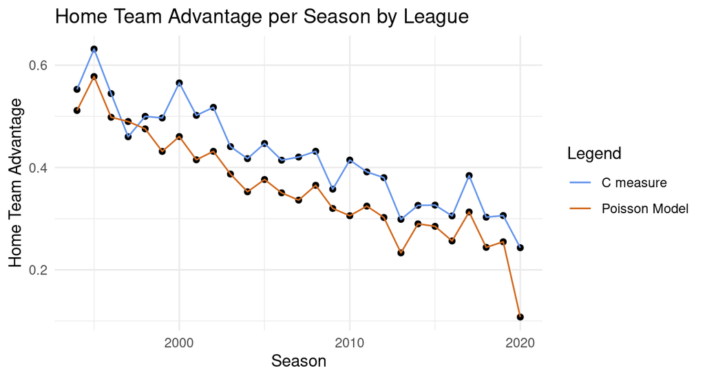

## Calculating Adjusted HHI and Noll-Scully

- Herfindahl-Hirschman index comes from economics, and is a commonly accepted measure of market concentration․ Increasing number of the teams affects lower bound (in some cases upper bound as well)

\[aHHI = \sum_{i = 1}^{n} \left(\frac{p_i}{ \sum_{i = 1}^{n} p_i } \right)^2 - \frac{1}{n}\]

- The Noll-Scully compares what a league actually looks like to what it would ideally look like.
- The higher the number means that there is less competition, and if it is closer to 1, it means that the competitive balance is higher.

\[\sigma_{relative} = \frac{\sigma}{ 0.5 / \sqrt{m} }\]

## Combined measure for HT Advantage and Adjusted HHI

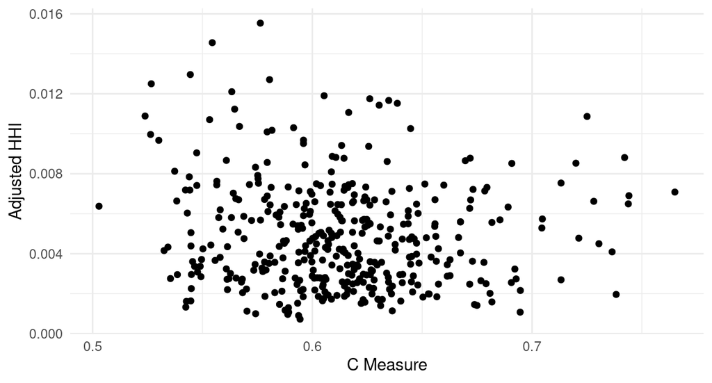

## Combined measure for HT Advantage and Noll-Scully Number

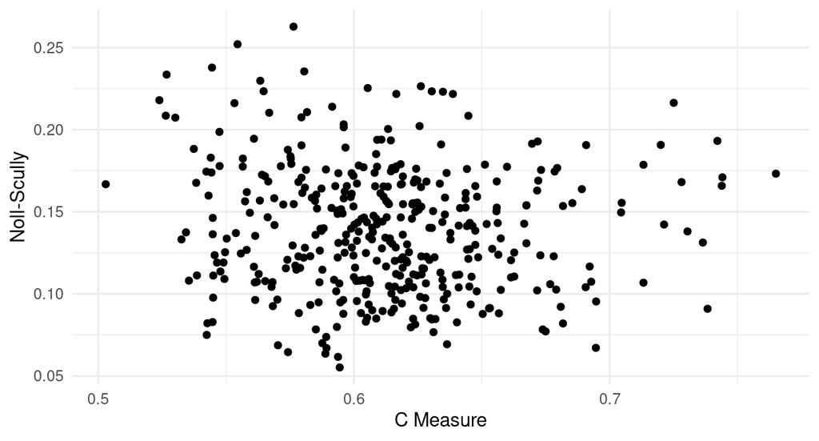

## Entropy

- The relative-entropy measure of information theory is also used to measure seasonal competitive balance (Horowitz, 1997)
- Relative entropy, \(R = \frac{H}{H_M}\), measures the degree of uncertainty about which team might have won a randomly-selected game, relative to the maximum uncertainty possible.

\[R = \frac{\sum_{i=1}^{n} p_i\log_2(p_i)}{\sum_{i=1}^{n} \frac{1}{n}\log_2(\frac{1}{n})}\]

## Combined measure for HT Advantage and Entropy

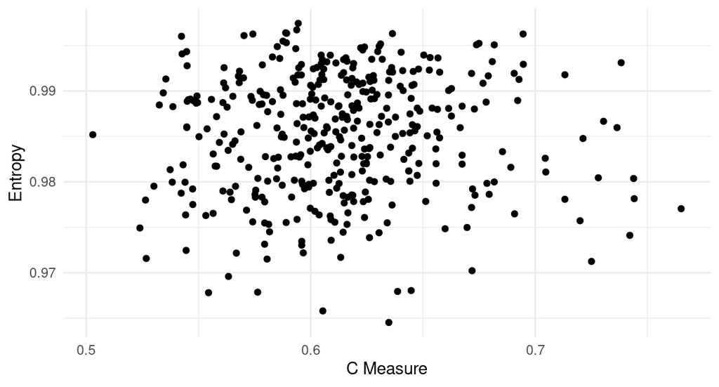

## Surprise Indices

The Surprise Index is another measure for CB. It is the ratio between P, the realized surprise points and M, the maximum number of surprise points that is possible when the teams are perfectly balanced.

- Two surprise points are given when a team looses from a lower ranked team and one point is awarded when the game ends in a tie. These points are weighted with the rank difference. (Groot and Groot, 2003) \[M = \frac{(N-1)N(N+1)}{3}\]

\[S = \frac{P}{M}\]

## Combined measure for HT Advantage and Surprise Points

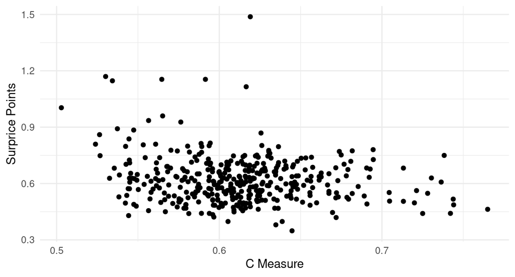

## Gini Competitive Balance

The Gini coefficient is originally developed to measure income inequalities. Schmidt (2001) and Schmidt & Berri (2001) use it to measure the inequality of winning percentages. The lower the Gini coefficient is, the more competitive the league is.

\[G = {\frac {\displaystyle {\sum _{i=1}^{n}\sum _{j=1}^{n}\left|x_{i}-x_{j}\right|}}{\displaystyle {2n^{2}{\bar {x}}}}}\]

## Combined measure for HT Advantage and Gini Coefficient

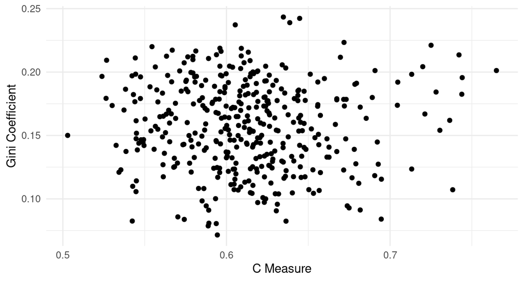

## All CB

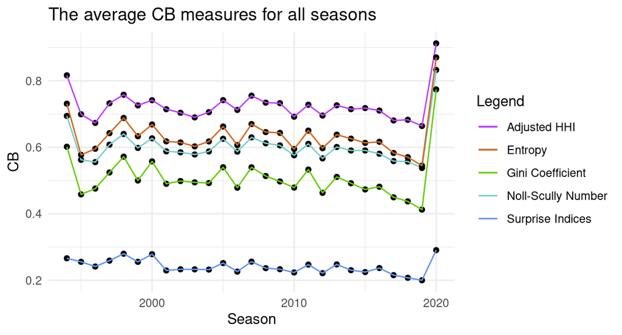

## Combined measure for HT Advantage and Entropy

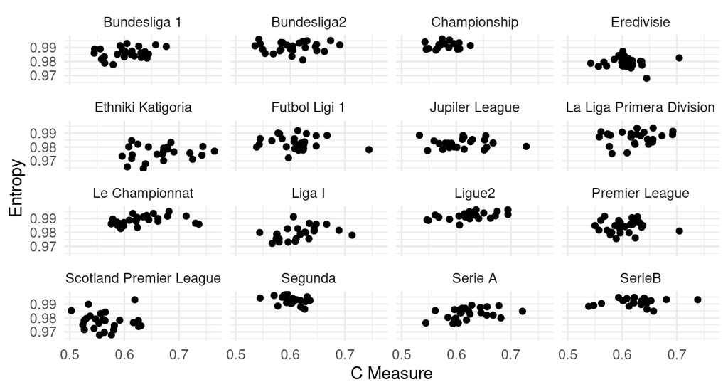

## Correlation matrix

We can see that we have a strong linear correlation among several methods of calculating the same metric. On the other hand, we see that very small correlation exists among two methods of calculating two metrics. Hence, one can conlude that there is not a strong linear relationship between home team advantage and competitive balance.

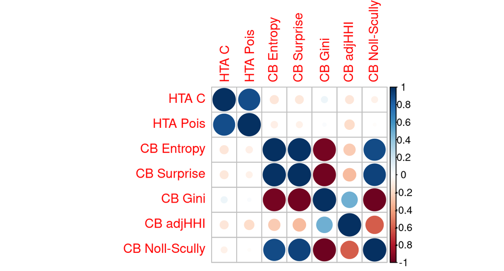

## Conclusion

Based on our analysis we have concluded that there is more correlation when considering a league separately. Also, comparing the different measures leads us to conclude that overall, the models between home team advantage and competitive balance do have some correlation, but it is not significant. There are also some extraordinary cases where some leagues are outliers, such as in the Premier League and Scotland. The best correlations were seen in leagues Le Championnat and League 2.

## Shiny App

[https://mev6zxu4yxgkxytg.shinyapps.io/GPPP/]

## References

P. Marek, F. Vávra. Comparison of Home Advantage in European Football Leagues (2020). Retrieved from https://bit.ly/3qv6fNX

I. Horowitz, The Increasing Competitive Balance in Major League Baseball (1997). Retrieved from https://bit.ly/3lPFuAe

M. Schmidt, D. Berri. Competitive Balance and Attendance: The Case of Major League Baseball (2001). Retrieved from https://bit.ly/37KSC4F

K. Goossens. Competitive Balance in European Football. Retrieved from https://bit.ly/2K0UMVC